# R Notebook

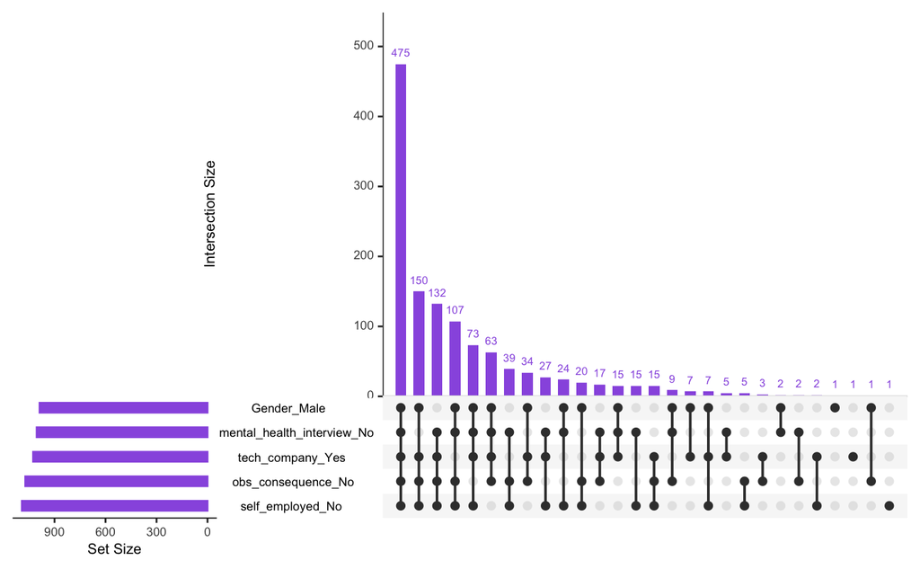

Intepreting the chart: I have about 1200 data points, about 988 (almost 1000) of them are male. The fact that 475 men said that: 1. they would not bring up a mental health issue with a potential employer in an interview (mental_health_interview_No), 2. worked for a tech company (tech_company_Yes), 3. had not heard of or observed negative consequences for coworkers with mental health conditions in their workplace (obs_consequence_No), 4. and were not self_employed (self_employed_No) - this variable being a little redundant with the tech company variable - is significant because it reveals that a significant plurality of men (48%) and over a third of respondents responded the same way.

If you add in the 132 people who were not men who also responded the same way to those 4 questions, then you end up nearly HALF of the entire dataset answering those questions the same way (48%).

It seems to me that at tech companies, people felt that they would not bring up mental health in an interview yet had never heard of or observed negative consequences for coworkers with mental health in their workplace, which suggests to me that it’s something people aren’t open with in their workplace.

Questions: - I wonder if those could be predictors, and also what the people who don’t fit this profile look like. - I wonder how the distribution is for women